# Reproducible Research: Peer Assessment 1

## Loading and preprocessing the data

First, we load the data, trying to be smart about not doing any more work than necessary. Messages indicate what loading is being done, or whether the code was able to use what data was available on the local file system.

```
## [Leveraging existing activity data file]
```

## What is mean total number of steps taken per day?

To answer this question, we compute the total number of steps per day, excluding missing values:

```r
data <- subset(raw.data, !is.na(raw.data$steps))

steps.by.date <- aggregate(steps ~ date, data = data, FUN = sum)
steps.by.date$imputed <- FALSE  # We use this later when combining with imputed data
```

A histogram of the steps per day shows the distribution of the total steps per day:

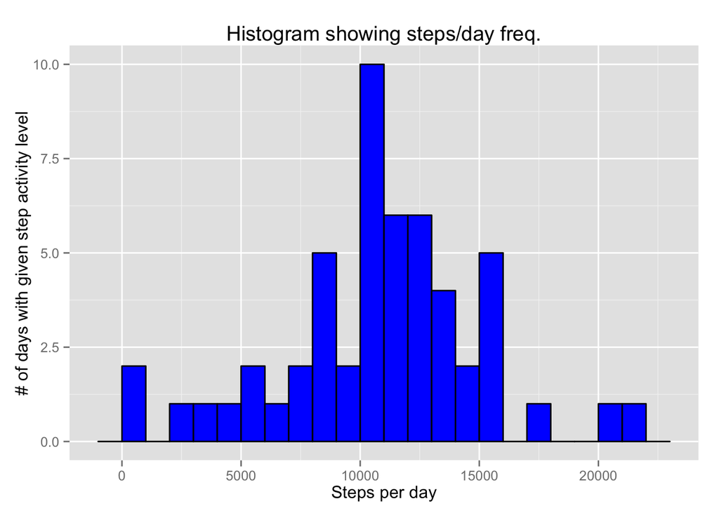

```r
# We will have several graphcs that can use the same label, so factor its definition
# into a single place for easier maintenance.
histogram.labels <- labs(title = "Histogram showing steps/day freq.",
                         x = "Steps per day",
                         y = "# of days with given step activity level")

basic.histogram <- ggplot(steps.by.date, aes(x=steps)) +
  geom_histogram(binwidth = 1000, fill="blue", color="black")  +
  histogram.labels

print(basic.histogram)
```

### Mean and median steps taken per day

The mean number of steps taken per day is 10766.19.

The median number of steps taken per day is 10765.

It will be more informative to see these combined with the graph, like so:

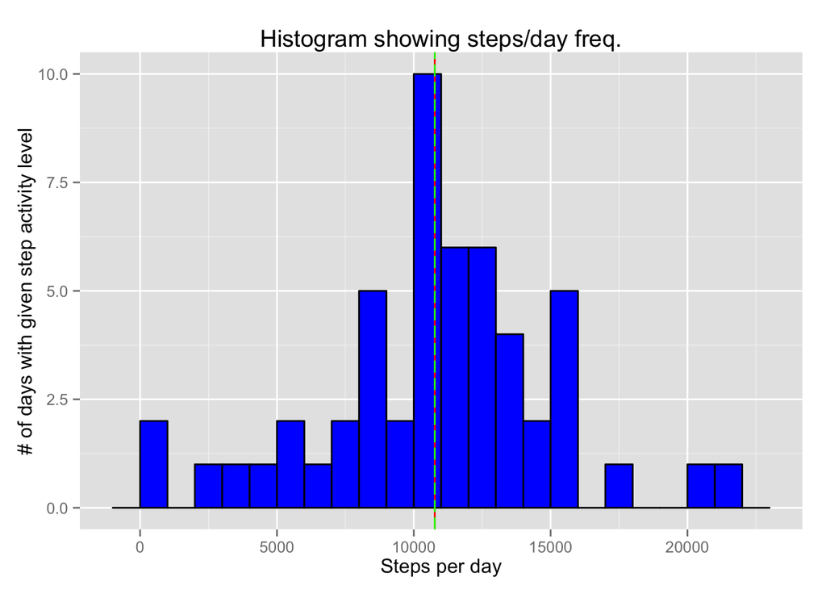

```r
histogram.with.mean.and.median = basic.histogram +
  geom_vline(xintercept=mean(steps.by.date$steps), color="red") +
  geom_vline(xintercept=median(steps.by.date$steps), color="green", linetype="longdash")

print(histogram.with.mean.and.median)
```

As is apparent, because these two numbers are so close, they overlap.

## What is the average daily activity pattern?

To answer this question, we compute the mean of the steps by interval, then show the data as a line plot of interval vs average number of steps, with some interesting characteristics:

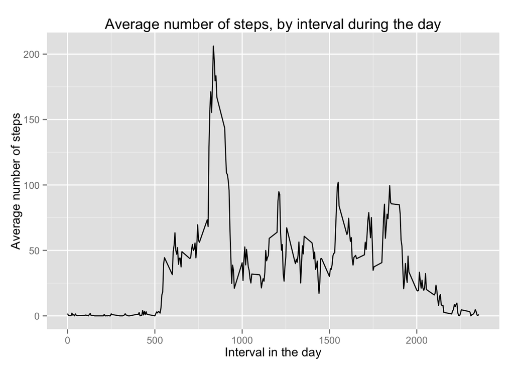

```r
average.steps <- aggregate(steps ~ interval, data = data, FUN = mean)

average.steps.plot <- ggplot(average.steps, aes(x = interval, y = steps)) +
  geom_line() +
  labs(title = "Average number of steps, by interval during the day",
       x = "Interval in the day", y = "Average number of steps")

print(average.steps.plot)
```

The interval with the maximum average number of steps is calculated by:

```r
average.steps.max <- average.steps[which.max(average.steps$steps),]
max.interval <- average.steps.max$interval

# compute values for showing the time of day when the max interval occurred
# Intervals are hours * 100 + minutes
max.interval.hour <- floor(max.interval/100)
max.interval.min <- max.interval %% 100
max.interval.time <- sprintf("%d:%02d %s", max.interval.hour,
  max.interval.min, if(max.interval.hour >= 12) "pm" else "am")
```

And its value is 835, or 8:35 am.

Showing this on the graph, we get:

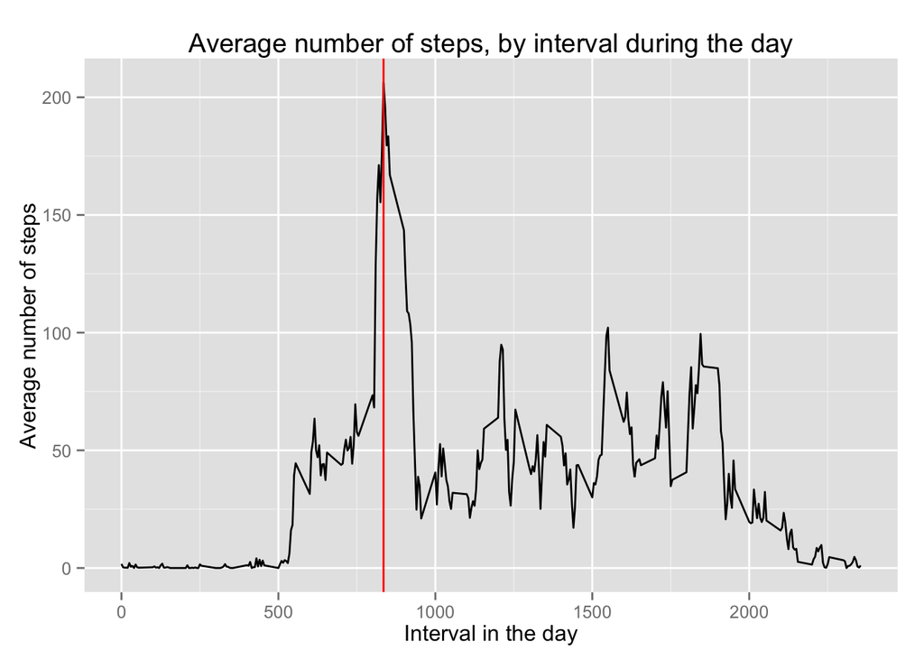

```r
print(average.steps.plot + geom_vline(xintercept=max.interval, color="red"))
```

## Imputing missing values

The data set contains many rows with missing values for the number of steps. The following code calculates and shows just how many rows have missing step information:

```r
print(sum(is.na(raw.data$steps)))
```

```
## [1] 2304
```

These missing step values may skew the actual averages, so we now explore correcting this defect by “imputing” values according to some algorithm for this missing values

One approach to correct the missing value situation is to devise a means of coming up with representative numbers of steps by interval, using the average numbers of steps per interval computed over the rest of the dataset.

```r
missing.steps.rows <- subset(raw.data, is.na(raw.data$steps))

# Replace the missing step values with the imputed value, which I have chosen to be
# the average steps for that interval where the steps are present.
for (i in seq_along(missing.steps.rows$steps)) {
  interval <- missing.steps.rows[i,]$interval
  missing.steps.rows[i,]$steps = average.steps[average.steps$interval == interval,]$steps
}

# Now glue both parts back together, and compute the mean&median steps by date for it
imputed.data <- rbind(missing.steps.rows, data)
imputed.steps.by.date <- aggregate(steps ~ date, data = imputed.data, FUN = sum)
# Mark these data as imputed, so they can be differentiated from the non-imputed data
# when they are combined below
imputed.steps.by.date$imputed <- TRUE

# Compute the requested average values
mean.imputed.steps.by.date <- mean(imputed.steps.by.date$steps)
median.imputed.steps.by.date <- median(imputed.steps.by.date$steps)

imputed.histogram <- ggplot(imputed.steps.by.date, aes(x=steps)) +
  geom_histogram(binwidth = 1000)  +
  geom_vline(xintercept = mean.imputed.steps.by.date, color = "red") +
  geom_vline(xintercept = median.imputed.steps.by.date, color="green", linetype="longdash") +
  histogram.labels
```

This yields the following side by side comparison plot:

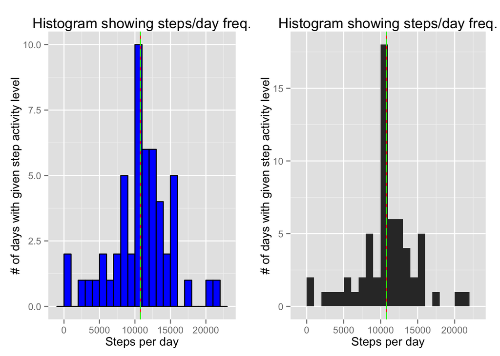

```r
# Now, show the results
grid.arrange(histogram.with.mean.and.median, imputed.histogram, nrow=1, ncol=2)
```

The mean and median for this plot are 10766.19 and 10766.19. This time, they are even more identical than with the non-imputed values.

Comparing these values with the original means and medians:

|  | Original values | With imputed |
| --- | --- | --- |
| Mean | 10766.19 | 10766.19 |
| Median | 10765 | 10766.19 |

At first this may seem surprising that they are identical, but it follows from the fact that all that was added were existing average values, which should not change the means other than to concentrate them a bit more.

#### Refining the comparison

This plot above shows there seems to be concentration of the frequences when the imputed vaues are taken into account, but it is somewhat misleading in that the scales on the two graphs are not the same.

So, below is shown a different plot that emphasizes the differences when both plots are shown together.

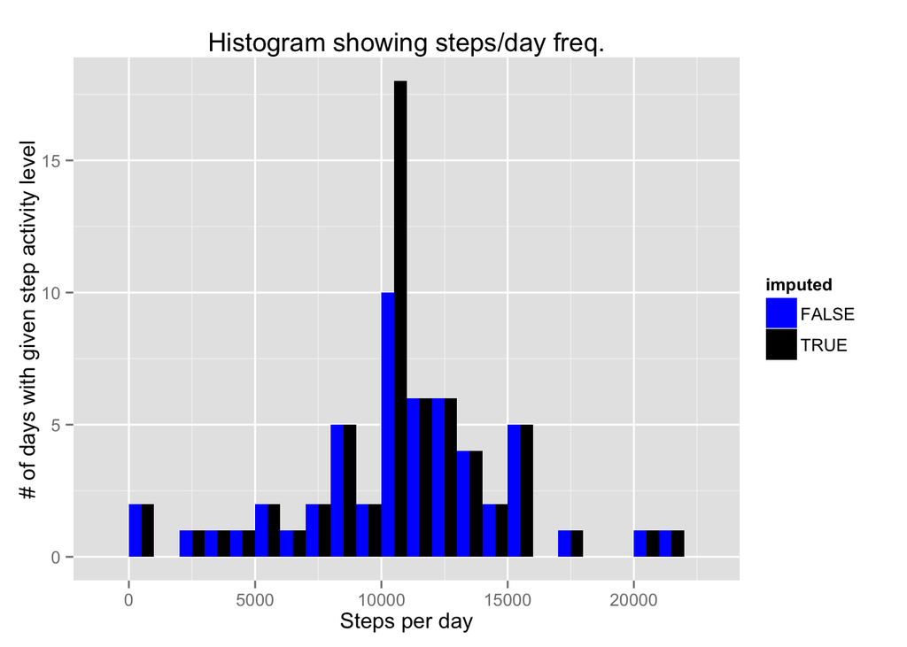

```r
combined.steps.data <- rbind(imputed.steps.by.date, steps.by.date)

combined.histograms <- ggplot(combined.steps.data, aes(x=steps, fill = imputed) ) +
  geom_histogram(binwidth = 1000, position="dodge")  +
  scale_fill_manual(values=c('blue','black')) +
  histogram.labels

print(combined.histograms)
```

What appears to be going on here is that, for the most part, the effect of adding additional imputed values does not change the graph much except for the values that are fall into the mean value range.

This is a somewhat surprising result. What I believe is the explanation is as follows:

- there are 61 days total in the data set
- 8 of which are missing step data, 53 have step data
- when the 8 days are gifted with synthetic data, taken from the average interval values, it makes them have a number of steps per day that reflects the average values across all the remaining days
- this means that the 8 additional days essentially fall into the bin that contains the most days with the average values of the 53 original days, thus causing an increase in height for that bin alone
- the combined graph shows that the bin containing the largest number of days with the “average” total number of steps/day is increased by 8, which is the newly added 8 days with imputed data

## Are there differences in activity patterns between weekdays and weekends?

To address this question, it is necessary to first map the dates in the data to days of the week and then classify those as either weekend or weekdays. It will then be possible to do a facet based plot showing the activity levels on the two types of days.

```r
data.days.of.the.week <- weekdays(as.Date(imputed.data$date))
imputed.data$dayType <- factor(ifelse(data.days.of.the.week %in% c('Saturday', 'Sunday'), 'weekend', 'weekday'))
```

Now simply compute the average steps taken by interval and dayType, and display the result.

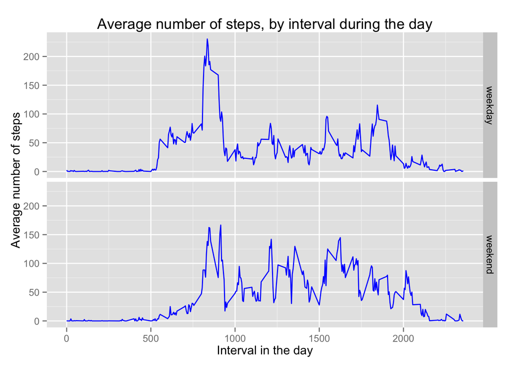

```r
average.steps <- aggregate(steps ~ interval + dayType, data = imputed.data, FUN = mean)

average.steps.plot <- ggplot(average.steps, aes(x = interval, y = steps)) +
  geom_line(color = "blue") +
  facet_grid(dayType ~ .) +
  labs(title = "Average number of steps, by interval during the day",
       x = "Interval in the day", y = "Average number of steps")

print(average.steps.plot)
```

The data indicates that the person in question (during the range of dates measured), appears to get up later during the weekend, and be a bit more active consistently throughout the day as compared with during the ordinary work weeks.